# EFEK PROMOSI DENGAN PEMBERIAN KUPON VOUCHER TERHADAP KEMBALINYA USER UNTUK BERTRANSAKSI TANPA VOUCHER

Muhajir Akbar Hasibuan Muhajirakbarhsb@gmail.com

Ketika menjalankan promosi, setiap organisasi harus memastikan ada keseimbangan antara nilai promosi yang dikeluarkan dengan goal yang diharapkan. Membakar sebanyak mungkin uang mungkin akan menarik banyak user, tapi apakah user-user tersebut akan kembali tanpa promosi?

Dalam kasus ini akan dilakukan analisis dari hasil pilot testing dari dua promosi yang telah dilakukan. Dalam skema pertama, satu user group diberikan voucher senilai 10K dan grup yang lain diberikan voucher 25K. Tujuan dari analisis ini adalah untuk mengetahui jawaban dari pertanyaan ini:

1. Jumlah promosi mana yang akan menarik user untuk bertransaksi lebih banyak?

Data yang diberikan memiliki informasi sebagai berikut: • user_id – identifikasi unik untuk tiap user • merchant_id - identifikasi unik untuk tiap penjual • promotion_type – tipe promosi, antara 10K atau 25K • three_trx – jika user melakukan 3 transaksi setelah diberikan voucher, kolom ini akan memiliki nilai 1. Jika tidak, nilainya 0 • five_trx - jika user melakukan 5 transaksi setelah diberikan voucher, kolom ini akan memiliki nilai 1. Jika tidak, nilainya 0

Langkah analisis untuk kasus ini terbagi menjadi dua bagian, yang pertama merupakan bagian data wrangling dan anlisis lalu bagian kedua meliputi visualisasi data.

**1. DATA WRANGLING - CLEANING**

```r
library(dplyr) #package untuk data manipulation
library(sqldf) #package untuk menjalankan sql languange dalam R
dqlab=read.csv("preliminary_dataset.csv", header = TRUE) #memanggil file yang berbentuk csv
sapply(dqlab, function(x) sum(is.na(x))) #dilakukan untuk menemukan missing value
```

```
##            X      user_id  merchant_id coupon_value    three_trx
##            0            3            3            3            3
##     five_trx
##            3
```

```r
dqlab <- na.omit(dqlab) # menghapus baris yang terdapat missing value
sapply(dqlab, function(x) sum(is.na(x))) # dilakukan untuk pengecekan kembali apakah masih terdapat data hilang
```

```
##            X      user_id  merchant_id coupon_value    three_trx
##            0            0            0            0            0
##     five_trx
##            0
```

```r
dqlab <- select(dqlab, -X) #variabel x tidak memiliki makna apapun jadi bisa dihilangkan
merchant= dqlab$merchant_id
merchant_id= as.character(merchant) #variabel merchant diubah kedalam bentuk karakter, sehingga ketika dilakukan visualisasi nantinya x-axis tidak menjadi sebuah interval karena merchant id pada data merupakan data dengan tipe integer
dqlab <- select(dqlab, -merchant_id) #menghapus variabel merchant yang masih bertipe integer di data frame
data2 <- data.frame(merchant_id, dqlab) #menggabungkan variabel merchant id yang sudah menjadi character dengan data frame
dqlab <- data2
dqlab <- dqlab[!(dqlab$three_trx=="0" & dqlab$five_trx==1),] #menghapus baris yang dengan kondisi three_trx = 0, five_trx = 1
str(dqlab) #melihat tipe data dari dataframe
```

```
## 'data.frame':    8169 obs. of  5 variables:
##  $ merchant_id : Factor w/ 50 levels "105870","124542",..: 40 28 41 38 20 20 36 27 27 21 ...
##  $ user_id     : int  384212 521382 492364 565771 636203 788042 318404 269330 709364 577125 ...
##  $ coupon_value: int  25000 25000 25000 25000 25000 25000 25000 25000 25000 25000 ...
##  $ three_trx   : int  0 0 0 0 0 0 0 1 0 0 ...
##  $ five_trx    : int  0 0 0 0 0 0 0 0 0 0 ...
```

```r
head(dqlab)
```

```
##   merchant_id user_id coupon_value three_trx five_trx
## 1      817754  384212        25000         0        0
## 2      571603  521382        25000         0        0
## 3      841900  492364        25000         0        0
## 4       74426  565771        25000         0        0
## 5      404793  636203        25000         0        0
## 6      404793  788042        25000         0        0
```

```r
nrow(distinct(dqlab, user_id)) #untuk melihat apakah ada user yang melakukan pembelian lebih dari satu kali
```

```
## [1] 8143
```

```r
nrow(distinct(dqlab, merchant_id)) #untuk melihat berapa jumlah merchant
```

```
## [1] 50
```

Proses data wrangling pada bagian pertama difokuskan untuk mengidentifikasi missing value pada data, dapat dilihat bahwa terdapat tiga baris data yang memiliki missing value, sehingga dilakukan proses cleaning dengan cara menghapus data yang memiliki missing value, proses ini dilakukan dengan fungsi na.omit. tahap selanjutnya adalah menghapus kolom x, kolom x dihapus karena tidak memiliki makna, fungsinya sebagai nomor dapat digantikan dengan melihat row number pada table. Proses selanjutnya adalah melakukan pengecekan pada tipe data, pada bagian ini dilakukan pergantian tipe data pada kolom merchant_id dari yang sebelumnya berbentuk integer diubah kedalam bentuk character, sehingga ketika nantinya dilakukan visualisasi, x-axis tidak menjadi sebuah interva.Proses berikutnya adalah menghapus data dengan kondisi three_trx = 0 dan five_trx = 1, bagian ini penting untuk dilakukan karena, tidak mungkin seseorang telah melakukan transaksi sebanyak 5 kali jika ia belum melakukan transaksi sebanyak 3 kali.

Berdasarkan Print Output diatas dapat dilihat bahwa data yang telah clean memiliki 8169 observasi dan 5 variabel, angka 8143 menerangkan bahwa ada 8143 user id unik yang melakukan transaksi dengan kata lain ada beberapa user yang melakukan transaksi di merchant_id yang berbeda, sedangkan angka 50 pada ouput merukan jumlah merchant_id yang terdapat pada sampel data.

**1.2. DATA WRANGLING - TRANSFORM**

```r
#filter data berdasarkan user id yang membeli lebih di satu merchant
a= sqldf("SELECT * FROM dqlab WHERE user_id IN (SELECT user_id FROM dqlab GROUP BY user_id HAVING COUNT(*) > 1) GROUP BY user_id, merchant_id, coupon_value, three_trx, five_trx;")

a25k = dplyr::filter(a, coupon_value %in% c("25000")) #mengambil dataset pembeli yang membeli lebih di satu merchant berdasarkan nilai kupon 25000
b25k = dplyr::filter(a, coupon_value %in% c("10000"))  #mengambil dataset pembeli yang membeli lebih di satu merchant berdasarkan nilai kupon 10000


#filter data lengkap berdasarkan nilai dari kupon
data25k = dplyr::filter(dqlab, coupon_value %in% c("25000"))
head(data25k)
```

```
##   merchant_id user_id coupon_value three_trx five_trx
## 1      817754  384212        25000         0        0
## 2      571603  521382        25000         0        0
## 3      841900  492364        25000         0        0
## 4       74426  565771        25000         0        0
## 5      404793  636203        25000         0        0
## 6      404793  788042        25000         0        0
```

```r
data10k = dplyr::filter(dqlab, coupon_value %in% c("10000"))
t325k= sqldf("SELECT * FROM data25k WHERE three_trx = 1;")
head(t325k)
```

```
##   merchant_id user_id coupon_value three_trx five_trx
## 1      531400  269330        25000         1        0
## 2      531400  575881        25000         1        0
## 3       74426  428793        25000         1        0
## 4      404793  639660        25000         1        1
## 5      658432  173749        25000         1        1
## 6      571603  198092        25000         1        0
```

```r
t525k= sqldf("SELECT * FROM data25k WHERE five_trx = 1;")

t310k= sqldf("SELECT * FROM data10k WHERE three_trx = 1;")
t510k= sqldf("SELECT * FROM data10k WHERE five_trx = 1;")
notrx25k= sqldf("SELECT * FROM data25k WHERE three_trx = 0;")

notrx10k= sqldf("SELECT * FROM data10k WHERE three_trx = 0;")
ft325k= sqldf("SELECT merchant_id, COUNT(*) FROM t325k GROUP BY merchant_id ORDER BY 2 DESC;")
ft525k= sqldf("SELECT merchant_id, COUNT(*) FROM t525k GROUP BY merchant_id ORDER BY 2 DESC;")
head(ft525k)
```

```
##   merchant_id COUNT(*)
## 1      403849        6
## 2      324950        4
## 3      841900        3
## 4      666703        1
## 5      658432        1
## 6      571603        1
```

```r
ft310k= sqldf("SELECT merchant_id, COUNT(*) FROM t310k GROUP BY merchant_id ORDER BY 2 DESC;")
ft510k= sqldf("SELECT merchant_id, COUNT(*) FROM t510k GROUP BY merchant_id ORDER BY 2 DESC;")
fn25k= sqldf("SELECT merchant_id, COUNT(*) FROM notrx25k GROUP BY merchant_id ORDER BY 2 DESC;")
fn10k= sqldf("SELECT merchant_id, COUNT(*) FROM notrx10k GROUP BY merchant_id ORDER BY 2 DESC;")
ftotal= sqldf("SELECT merchant_id, COUNT(*) FROM dqlab GROUP BY merchant_id ORDER BY 2 DESC;")
```

Transformasi data merupakan proses yang sangat penting dilakukan, pada bagian ini dilakukan proses transformasi data frame dengan cara melakukan filter menggunakan bahasa SQL yang dijalankan di R dengan menggunakan package sqldf, data frame yang telah ditranformasi ini berguna untuk memudahkan proses visualisasi.

Data tranformasi yang diberikan memiliki informasi sebagai berikut:

•a = Filter data berdasarkan user id yang membeli lebih di satu merchant

•a25k = Dataset pembeli yang membeli lebih di satu merchant berdasarkan nilai kupon 25000

•b25k = Dataset pembeli yang membeli lebih di satu merchant berdasarkan nilai kupon 10000

•data25k = Dataset berdasarkan nilai kupon sebesar 25000

•data10k = Dataset berdasarkan nilai kupon sebesar 10000

•t325k = Dataset user mendapatkan kupon 25000 dan berbelanja 3 kali

•t525k = Dataset user mendapatkan kupon 25000 dan berbelanja 5 kali

•t310k = Dataset user mendapatkan kupon 10000 dan berbelanja 3 kali

•t510k = Dataset user mendapatkan kupon 10000 dan berbelanja 5 kali

•notrx25k = Dataset berdasarkan nilai kupon sebesar 25000 dan berbelanja kurang dari 3 kali

•notrx10k = Dataset berdasarkan nilai kupon sebesar 10000 dan berbelanja kurang dari 3 kali

•ft325k = Frekuensi berbelanja pada setiap merchant berdasarkan user yang mendapatkan kupon 25000 dan  
berbelanja 3 kali diurutkan dari terbesar ke terkecil

•ft525k = Frekuensi berbelanja pada setiap merchant berdasarkan user yang mendapatkan kupon 25000 dan

berbelanja 5 kali diurutkan dari terbesar ke terkecil

•ft310k = Frekuensi berbelanja pada setiap merchant berdasarkan user yang mendapatkan kupon 10000 dan berbelanja 3 kali diurutkan dari terbesar ke terkecil

•ft510k = Frekuensi berbelanja pada setiap merchant berdasarkan user yang mendapatkan kupon 10000 dan berbelanja 5 kali diurutkan dari terbesar ke terkecil

•fn25k = frekuensi berbelanja pada setiap merchant berdasarkan user yang mendapatkan kupon 25000 dan berbelanja kurang 3 kali diurutkan dari terbesar ke terkecil

•fn10k = Frekuensi berbelanja pada setiap merchant berdasarkan user yang mendapatkan kupon 10000 dan berbelanja kurang 3 kali diurutkan dari terbesar ke terkecil

•ftotal = Frekuensi berbelanja pada setiap merchant berdasarkan user diurutkan dari terbesar ke terkecil

Data yang bersih merupakan data yang telah melalui proses wrangling sehingga data menjadi minim noise sehingga meminimalisisr kemungkinan terjadinya bias pada saat pengolahan data maupun visualisasi data.

**1.3. ANALISIS DATA**

Analisis data yang dilakukan adalah regresi logistik biner, dengan melakukan regresi ini akan didapatkan hasil bagaimana peluang seorang user akan membeli sebanyak 3 atau 5 kali berdasarkan voucher kupon yang diberikan dan akan menampilkan hasil apakah perbedaan itu signifikan atau tidak. Analisis ini dibagi menjadi dua bagian, pada bagian pertama variabel dependent adalah three_trx dan pada bagian kedua variabel dependent adalah five_trx dengan variabel independent adalah coupon value.

**- y = three_trx dan x = coupon_value**

```r
#Logistic Regression dengan y = three_trx dan x = coupon_value
library(aod)
```

```r
library(ggplot2)
head(dqlab)
```

```
##   merchant_id user_id coupon_value three_trx five_trx
## 1      817754  384212        25000         0        0
## 2      571603  521382        25000         0        0
## 3      841900  492364        25000         0        0
## 4       74426  565771        25000         0        0
## 5      404793  636203        25000         0        0
## 6      404793  788042        25000         0        0
```

```r
logit <- subset( dqlab, select = -c(merchant_id, user_id, five_trx ) ) # Langkah ini dilakukan untuk memilih kolom yang akan diinput ke data frame yang baru
head(logit)
```

```
##   coupon_value three_trx
## 1        25000         0
## 2        25000         0
## 3        25000         0
## 4        25000         0
## 5        25000         0
## 6        25000         0
```

```r
xtabs(~three_trx + coupon_value, data = logit) #dilakukan untuk menampilkan tabel kontingensi
```

```
##          coupon_value
## three_trx 10000 25000
##         0  3857  4047
##         1   119   146
```

```r
logit$coupon_value <- factor(logit$coupon_value) #Kolom coupon_value dijadikan sebagai faktor agar bersifat kategori
mylogit <- glm(three_trx ~ coupon_value , data = logit, family = "binomial") #Regresi Logisitik Biner
summary(mylogit)
```

```
##
## Call:
## glm(formula = three_trx ~ coupon_value, family = "binomial",
##     data = logit)
##
## Deviance Residuals:
##     Min       1Q   Median       3Q      Max
## -0.2662  -0.2662  -0.2465  -0.2465   2.6491
##
## Coefficients:
##                   Estimate Std. Error z value Pr(>|z|)
## (Intercept)       -3.47852    0.09307 -37.374   <2e-16 ***
## coupon_value25000  0.15640    0.12553   1.246    0.213
## ---
## Signif. codes:  0 '***' 0.001 '**' 0.01 '*' 0.05 '.' 0.1 ' ' 1
##
## (Dispersion parameter for binomial family taken to be 1)
##
##     Null deviance: 2338.3  on 8168  degrees of freedom
## Residual deviance: 2336.8  on 8167  degrees of freedom
## AIC: 2340.8
##
## Number of Fisher Scoring iterations: 6
```

```r
confint(mylogit) #Menampilkan Confident interval berdasarkan  log likelihood
```

```
##                         2.5 %    97.5 %
## (Intercept)       -3.66632951 -3.301162
## coupon_value25000 -0.08896539  0.403691
```

```r
confint.default(mylogit) #Menampilkan confident interval berdasarkan standar error
```

```
##                         2.5 %     97.5 %
## (Intercept)       -3.66094133 -3.2961016
## coupon_value25000 -0.08964687  0.4024408
```

```r
wald.test(b = coef(mylogit), Sigma = vcov(mylogit), Terms = 2) #menampilkan hasil chi-square test
```

```
## Wald test:
## ----------
##
## Chi-squared test:
## X2 = 1.6, df = 1, P(> X2) = 0.21
```

Bagian ini merupakan regresi logistik biner dengan variabel y = three_trx dan x = coupon_value

• Output dari Regresi Logit menjelaskan bahwa pemberian kupon sebesar 25000 akan menaikkan peluang odds user berbelanja sebanyak 3 kali transaksi sebesar 0.15642 daripada pemberian kupon sebesar 10000 akan tetapi perbedaan peluang ini tidak signifikan secara statistik karena memiliki p-value lebih besar daripada 0.05

• Pada ouput confident interval berdasarkan log likelihood menjelaskan bahwa perbedaan peluang odds antara pemberian kupon 25000 dan 10000 berkisar antara -0.088 sampai 0.4037

• Pada ouput confident interval berdasarkan standar error menjelaskan bahwa perbedaan peluang odds antara pemberian kupon 25000 dan 10000 berkisar antara -0.089 sampai 0.402

**- y = five_trx dan x = coupon_value**

```r
#Logistic Regressio dengan y = five_trx dan x = coupon_value

head(dqlab)
```

```
##   merchant_id user_id coupon_value three_trx five_trx
## 1      817754  384212        25000         0        0
## 2      571603  521382        25000         0        0
## 3      841900  492364        25000         0        0
## 4       74426  565771        25000         0        0
## 5      404793  636203        25000         0        0
## 6      404793  788042        25000         0        0
```

```r
logit2 <- subset( dqlab, select = -c(merchant_id, user_id, three_trx ) ) # Langkah ini dilakukan untuk memilih kolom yang akan diinput ke data frame yang baru
head(logit2)
```

```
##   coupon_value five_trx
## 1        25000        0
## 2        25000        0
## 3        25000        0
## 4        25000        0
## 5        25000        0
## 6        25000        0
```

```r
xtabs(~five_trx + coupon_value, data = logit2) #dilakukan untuk menampilkan tabel kontingensi
```

```
##         coupon_value
## five_trx 10000 25000
##        0  3960  4170
##        1    16    23
```

```r
logit2$coupon_value <- factor(logit2$coupon_value) #Kolom coupon_value dijadikan sebagai faktor agar bersifat kategori
mylogit2 <- glm(five_trx ~ coupon_value , data = logit2, family = "binomial") #Regresi Logisitik Biner
summary(mylogit2)
```

```
##
## Call:
## glm(formula = five_trx ~ coupon_value, family = "binomial", data = logit2)
##
## Deviance Residuals:
##     Min       1Q   Median       3Q      Max
## -0.1049  -0.1049  -0.1049  -0.0898   3.3213
##
## Coefficients:
##                   Estimate Std. Error z value Pr(>|z|)
## (Intercept)        -5.5114     0.2505 -22.001   <2e-16 ***
## coupon_value25000   0.3112     0.3263   0.954     0.34
## ---
## Signif. codes:  0 '***' 0.001 '**' 0.01 '*' 0.05 '.' 0.1 ' ' 1
##
## (Dispersion parameter for binomial family taken to be 1)
##
##     Null deviance: 494.69  on 8168  degrees of freedom
## Residual deviance: 493.76  on 8167  degrees of freedom
## AIC: 497.76
##
## Number of Fisher Scoring iterations: 8
```

```r
confint(mylogit2) #Menampilkan Confident interval berdasarkan  log likelihood
```

```
##                        2.5 %     97.5 %
## (Intercept)       -6.0457962 -5.0572793
## coupon_value25000 -0.3215073  0.9684936
```

```r
confint.default(mylogit2) #Menampilkan confident interval berdasarkan standar error
```

```
##                        2.5 %     97.5 %
## (Intercept)       -6.0023882 -5.0204329
## coupon_value25000 -0.3282977  0.9507647
```

```r
wald.test(b = coef(mylogit2), Sigma = vcov(mylogit2), Terms = 2) #menampilkan hasil chi-square test
```

```
## Wald test:
## ----------
##
## Chi-squared test:
## X2 = 0.91, df = 1, P(> X2) = 0.34
```

Bagian ini merupakan regresi logistik biner dengan variabel y = five_trx dan x = coupon_value

**2. Visualisasi Data**

Visualiasi data dilakukan dengan menggunakan barchart dengan x axis adalah merchant id dan y axis adalah frequensi transaksi dari merchant tersebut. Visualisasi ini terdiri dari 3 bagian yaitu berdasarkan user yang berbelanja 3 kali, 5 kali, dan kurang dari 3 kali

**2.1. Plot perbandingan merchant berdasarkan frequensi user yang berbelanja 3 kali menurut jenis kupon yang didapat**

```r
####### VISUALISASI ########
library(ggplot2)
library(viridis)
library(hrbrthemes)
#plot perbandingan merchant berdasarkan frequensi user yang berbelanja 3 kali menurut jenis kupon yang didapat
df1=ft310k[-c(11:26),] # mengambil 10 merchant yang paling banyak melakukan transaksi
df2=ft325k[-c(11:26),] # mengambil 10 merchant yang paling banyak melakukan transaksi

Jenis_Kupon <- rep(25000 , 10)
Jenis_Kupon=as.character(Jenis_Kupon)
df2 <- data.frame(df2, Jenis_Kupon)
Jenis_Kupon <- rep(10000 , 10)
Jenis_kupon=as.character(Jenis_Kupon)
df1 <- data.frame(df1, Jenis_Kupon)
plot1= merge(df1,df2, all= TRUE)
plot1
```

```
##    merchant_id COUNT... Jenis_Kupon
## 1       166745        4       10000
## 2       175577        4       10000
## 3         2940        4       10000
## 4         2940        9       25000
## 5       311420       15       10000
## 6       324950       24       25000
## 7       355706       11       10000
## 8       403849       17       25000
## 9       404793       22       10000
## 10      404793       23       25000
## 11      531400        7       10000
## 12      531400       13       25000
## 13      571603        7       25000
## 14      629060        4       10000
## 15      666703        3       25000
## 16      666703       14       10000
## 17       74426       11       25000
## 18      817754       16       10000
## 19      841900        8       25000
## 20      899747        9       25000
```

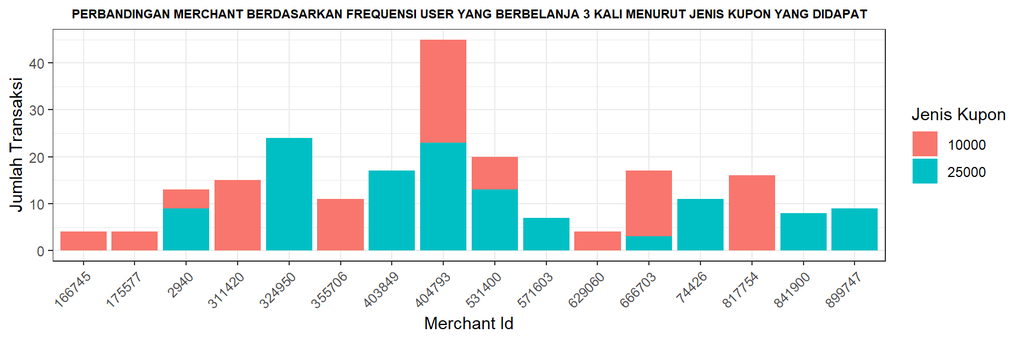

```r
p <-ggplot(plot1, aes(merchant_id, COUNT...)) + theme_bw()
p + geom_bar(stat = "identity", aes(fill = plot1$Jenis_Kupon)) + xlab("Merchant Id") + ylab("Jumlah Transaksi") + theme(axis.text.x = element_text(angle = 45, hjust = 1)) + labs(fill = "Jenis Kupon") + theme(plot.title = element_text(hjust = 0.5))  + theme(plot.title = element_text(size = 8, face = "bold")) + labs(title = "PERBANDINGAN MERCHANT BERDASARKAN FREQUENSI USER YANG BERBELANJA 3 KALI MENURUT JENIS KUPON YANG DIDAPAT" )
```

Gambar diatas merupakan visualisasi frequensi merchant id berdasarkan frequensi user yang berbelanja 3 kali setelah mendapatkan kupon diskon, hanya 10 merchant dengan jumlah user terbanyak pada masing-masing jenis kupon yang diambil, ada 4 merchant yang memiliki irisan untuk jenis kupon 10000 dan 25000. Merchant yang paling banyak menarik user untuk kembali berbelanja adalah merchant dengan id 404793 dengan jumlah total user berbelanja kembali setelah mendapat kupon 10000 adalah 22 dan setelah mendapat kupon 25000 adalah 23, berdasarkan gambar juga terlihat bahwa kupon diskon 25000 menarik lebih banyak pelanggan untuk berbelanja kembali, sebanyak 3 kali.

**2.2. Plot perbandingan merchant berdasarkan frequensi user yang berbelanja 5 kali menurut jenis kupon yang didapat**

```r
#plot perbandingan merchant berdasarkan frequensi user yang berbelanja 5 kali menurut jenis kupon yang didapat
df3=ft510k[-c(10:26),] # mengambil 9 merchant yang paling banyak melakukan transaksi
df4=ft525k[-c(10:26),] # mengambil 9 merchant yang paling banyak melakukan transaksi
df3
```

```
##   merchant_id COUNT(*)
## 1      817754        5
## 2      666703        2
## 3      404793        2
## 4      311420        2
## 5       74426        1
## 6      571603        1
## 7      518674        1
## 8      376444        1
## 9      355706        1
```

```r
df4
```

```
##   merchant_id COUNT(*)
## 1      403849        6
## 2      324950        4
## 3      841900        3
## 4      666703        1
## 5      658432        1
## 6      571603        1
## 7      531400        1
## 8      404793        1
## 9      376444        1
```

```r
Jenis_kupon <- rep(25000 , 9)
Jenis_kupon=as.character(Jenis_kupon)
df4 <- data.frame(df4, Jenis_kupon)
Jenis_kupon <- rep(10000 , 9)
Jenis_kupon=as.character(Jenis_kupon)
df3 <- data.frame(df3, Jenis_kupon)
plot2= merge(df3,df4, all= TRUE)
plot2
```

```
##    merchant_id COUNT... Jenis_kupon
## 1       311420        2       10000
## 2       324950        4       25000
## 3       355706        1       10000
## 4       376444        1       10000
## 5       376444        1       25000
## 6       403849        6       25000
## 7       404793        1       25000
## 8       404793        2       10000
## 9       518674        1       10000
## 10      531400        1       25000
## 11      571603        1       10000
## 12      571603        1       25000
## 13      658432        1       25000
## 14      666703        1       25000
## 15      666703        2       10000
## 16       74426        1       10000
## 17      817754        5       10000
## 18      841900        3       25000
```

```r
plot2
```

```
##    merchant_id COUNT... Jenis_kupon
## 1       311420        2       10000
## 2       324950        4       25000
## 3       355706        1       10000
## 4       376444        1       10000
## 5       376444        1       25000
## 6       403849        6       25000
## 7       404793        1       25000
## 8       404793        2       10000
## 9       518674        1       10000
## 10      531400        1       25000
## 11      571603        1       10000
## 12      571603        1       25000
## 13      658432        1       25000
## 14      666703        1       25000
## 15      666703        2       10000
## 16       74426        1       10000
## 17      817754        5       10000
## 18      841900        3       25000
```

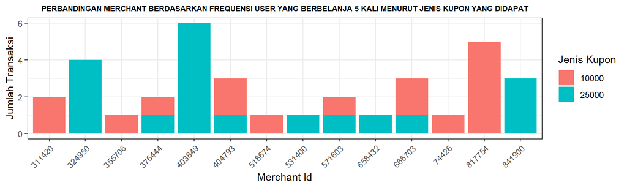

```r
p2 <-ggplot(plot2, aes(merchant_id, COUNT...)) + theme_bw()
p2 + geom_bar(stat = "identity", aes(fill = plot2$Jenis_kupon)) + xlab("Merchant Id") + ylab("Jumlah Transaksi") + theme(axis.text.x = element_text(angle = 45, hjust = 1)) + labs(fill = "Jenis Kupon") + theme(plot.title = element_text(hjust = 0.5)) + theme(plot.title = element_text(size = 8, face = "bold")) + labs(title = "PERBANDINGAN MERCHANT BERDASARKAN FREQUENSI USER YANG BERBELANJA 5 KALI MENURUT JENIS KUPON YANG DIDAPAT")
```

**2.3 Plot perbandingan merchant berdasarkan frequensi user yang berbelanja kurang dari 3 kali**

```r
#plot perbandingan merchant berdasarkan frequensi user yang berbelanja kurang dari 3 kali
df5=fn10k[-c(11:10000),] # mengambil 10 merchant yang paling banyak melakukan transaksi
df6=fn25k[-c(11:10000),] # mengambil 10 merchant yang paling banyak melakukan transaksi
df5
```

```
##    merchant_id COUNT(*)
## 1       666703      766
## 2       404793      475
## 3       311420      452
## 4       166745      369
## 5       355706      364
## 6       531400      258
## 7       817754      215
## 8       376444      214
## 9         2940      184
## 10      324950       96
```

```r
df6
```

```
##    merchant_id COUNT(*)
## 1       404793      670
## 2       531400      655
## 3       324950      396
## 4       841900      276
## 5         2940      243
## 6        74426      205
## 7       571603      186
## 8       403849      186
## 9       899747      184
## 10       16153      126
```

```r
Jenis_kupon <- rep(25000 , 10)
Jenis_kupon=as.character(Jenis_kupon)
df6 <- data.frame(df6, Jenis_kupon)
Jenis_kupon <- rep(10000 , 10)
Jenis_kupon=as.character(Jenis_kupon)
df5 <- data.frame(df5, Jenis_kupon)
plot3= merge(df5,df6, all= TRUE)
plot3
```

```
##    merchant_id COUNT... Jenis_kupon
## 1        16153      126       25000
## 2       166745      369       10000
## 3         2940      184       10000
## 4         2940      243       25000
## 5       311420      452       10000
## 6       324950       96       10000
## 7       324950      396       25000
## 8       355706      364       10000
## 9       376444      214       10000
## 10      403849      186       25000
## 11      404793      475       10000
## 12      404793      670       25000
## 13      531400      258       10000
## 14      531400      655       25000
## 15      571603      186       25000
## 16      666703      766       10000
## 17       74426      205       25000
## 18      817754      215       10000
## 19      841900      276       25000
## 20      899747      184       25000
```

```r
plot3
```

```
##    merchant_id COUNT... Jenis_kupon
## 1        16153      126       25000
## 2       166745      369       10000
## 3         2940      184       10000
## 4         2940      243       25000
## 5       311420      452       10000
## 6       324950       96       10000
## 7       324950      396       25000
## 8       355706      364       10000
## 9       376444      214       10000
## 10      403849      186       25000
## 11      404793      475       10000
## 12      404793      670       25000
## 13      531400      258       10000
## 14      531400      655       25000
## 15      571603      186       25000
## 16      666703      766       10000
## 17       74426      205       25000
## 18      817754      215       10000
## 19      841900      276       25000
## 20      899747      184       25000
```

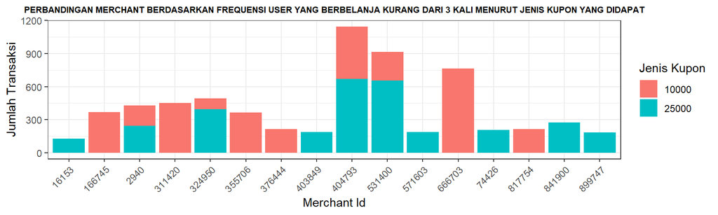

```r
p3 <-ggplot(plot3, aes(merchant_id, COUNT...)) + theme_bw()
p3 + geom_bar(stat = "identity", aes(fill = plot3$Jenis_kupon)) + xlab("Merchant Id") + ylab("Jumlah Transaksi") + theme(axis.text.x = element_text(angle = 45, hjust = 1)) + labs(fill = "Jenis Kupon") + theme(plot.title = element_text(hjust = 0.5)) + theme(plot.title = element_text(size = 8, face = "bold")) + labs(title = "PERBANDINGAN MERCHANT BERDASARKAN FREQUENSI USER YANG BERBELANJA KURANG DARI 3 KALI MENURUT JENIS KUPON YANG DIDAPAT")
```

**KESIMPULAN**

Untuk menjawab pertanyaan “Jumlah promosi mana yang akan menarik user untuk bertransaksi lebih banyak?” maka ada 4 poin jawaban:

**•Secara jumlah, kupon diskon sebesar 25000 menarik user untuk bertransaksi lebih banyak.**

**• kupon diskon sebesar 25000 memiliki peluang menarik kembali pelanggan lebih besar daripada kupon 10000, akan tetapi perbedaan peluangnya tidak signifikan secara statistik.**

**• Plot visualisasi menunjukkan hanya sedikit sekali user yang kembali berbelanja setidaknya 3 kali setelah mendapatkan kupon.**